# LRR des poissons d’eau douce de BFC

10_selection_especes

PabloVigneron

2026-04-28

Script : 10_selection_especes

Après avoir sélectionné les points de prélèvements et les opérations de pêche de l’aire géographique ciblée, un tri sur les données des espèces péchées durant ces opérations est réalisé. Il s’agit de retirer du jeu initial les données non nécessaires ou obsolètes pour notre étude.

# 1 Installation

## 1.1 Chargement des packages et des données

```r
library(tidyverse)
library(aspe)
library(ggrepel)
library(janitor)
library(scales)
```

```r
load(file = "../processed_data/selection_pop_ope.rda")
```

Nous avons besoin de charger la table *aspe* des données de mesures individuelles (cette dernière est lourde, elle peut donc mettre un certain temps à charger).

```r
rdata_tables <- misc_nom_dernier_fichier(
  repertoire = "../../../../Liste_rouge_BFC/raw_data",
  pattern = "^tables")
load(rdata_tables) # Chargement des données
```

# 2 Chargement de la table aspe des données de mesures individuelles

```r
mei_table <- misc_nom_dernier_fichier(
  repertoire = "../../../../Liste_rouge_BFC/raw_data",
  pattern = "^mei")
load(mei_table) # Chargement des données
```

# 3 Chargement de la base taxref

Pour constituer la liste complètes des espèces à évaluer de la liste rouge régionale de BFC, on importe la base **taxref_v18**. Pour pouvoir ajouter les libéllés de nom d’espèces au jeu de donnée de base par la suite, on importe un dataframe avec les codes espèces de la BDD Aspe **esp_code_alternatif**.

```r
base_tax_ref_aspe <- readxl::read_xlsx("../raw_data/ASPE_Suivi référentiel taxon_20250603 (1).xlsx", skip = 3)
base_tax_ref_uicn <- readr::read_delim('../raw_data/TAXREFv18.txt')
```

```r
tax_ref_uicn <- base_tax_ref_uicn %>%
  clean_names() %>%
  select(
    phylum,
    classe,
    ordre,
    famille,
    sous_famille,
    cd_ref,
    cd_nom,
    nom_complet,
    nom_valide,
    nom_vern,
    lb_nom,
    fr
  ) %>%
  filter(classe == "Actinopterygii" | classe == "Petromyzonti") %>%
  select(cd_nom, classe, ordre, famille, nom_valide, nom_vern,lb_nom ) %>%
  rename(code_taxref = cd_nom,
         nom_commun = nom_vern,
         nom_scientifique = lb_nom)
```

```r
tax_ref_aspe <- base_tax_ref_aspe %>%
  clean_names() %>%
  rename(esp_code_alternatif = code_alternatif_aspe,
         localite = hexagone_h_outre_mer_om,
         nom_vernaculaire = nom_commun,
         taxon = poisson_p_macro_crustaces_mc_amphibien_a) %>%
  filter(localite == "H",
         taxon == "P") %>%
  select(esp_code_alternatif, nom_vernaculaire, nom_latin, code_taxref, esp_code_alternatif)
```

On importe également une liste d’espèces réalisé par l’OFB en 2016 avec les statut d’autochtonie qu’on appelera **liste_esp_bfc**.

```r
liste_esp_bfc <- readxl::read_xlsx("../raw_data/espèces de poisson BFC.xlsx") %>%
  rename(esp_code_alternatif = "Code espèce") %>%
  mutate(esp_code_alternatif = fct_recode(esp_code_alternatif, "GTN" = "GOT"))  # Correction de l'ancien code du gobie à tâche noire de GOT en GTN
```

# 4 Constitution du jeu de données

## 4.1 Création du dataframe

Un nouveau jeu de données *esp_ope_selection* est créé à partir des stations et des opérations retenues dans la passerelle. Il contient les données spécifiques aux opérations : les résultats des pêches et certaines données de contexte (surface de pêche / date de pêche / effectifs / lots de poissons / données individuelles).

```r
esp_ope_selection <- passerelle %>% # dataframe contenant toutes les espèces présentes dans les opérations de pêches sélectionnées
  left_join(y=lot_poissons %>% # Ajout des lots de poissons
              select(lop_id,
                     esp_id = lop_esp_id,
                     lop_effectif)) %>%
  left_join(y= ref_espece %>% # Ajout des références des espèces péchées
               select(esp_id,
                      esp_code_alternatif)) %>%
  left_join(y=operation %>%
               select(ope_id,
                       ope_surface_calculee, # Ajout des surfaces de pêches
                       passage$pas_numero)) %>%
  mef_ajouter_ope_date() %>%  # Ajout des dates de pêches
  select(ope_id,
         lop_effectif,
         lop_id,
         esp_code_alternatif,
         annee,
         ope_surface_calculee) %>%
  distinct()
```

## 4.2 Tri du dataframe

Dans le cadre de notre étude, seules les espèces de poissons d’eau douce nous intéressent. Nous retirons alors les autres espèces du jeu de données *esp_ope_selection* établis dans les paramètres (cf params : “especes_a_retier”)

- Différents éco-types de Carpe (“CCX” _ “CMI” _ “CCU”) sont rassemblés sous un même code *esp_code_alternatif* : “CCO”.
- “APP”,“ASA”, “OCL”, “PCC”,“PFL” sont retirées car ce sont des espèces d’écrevisses
- “BRX”,“CAX”,“CCU”,“GOX”, “LPX”, “CYP” sont retirées car ce sont des espèces indéterminées.
- “HBG” : Hybride Brème/Gardon

A finir la prise de décision !!! :

- “CAA” est le nouveau code de “CAD”
- “VAR” : arrivé de la vandoise rostrée où modification de l’identification de “VAN”?
- “ROI” Rotengle italien
- “GOU”=> “GOO” : à partir d’environ 2018 : changement d’identification le Goujon (GOU) devient le Goujon occitan (GOO)

```r
esp_ope_selection <- esp_ope_selection %>%
  mutate(esp_code_alternatif =
           case_when(
             esp_code_alternatif %in% c("CCX", "CMI", "CCU") ~ "CCO",
             # Transformation CCX, CMI et CCU en CCO
             TRUE ~ esp_code_alternatif
           )) %>%
  filter(!(esp_code_alternatif %in% params$especes_a_retirer)) %>% # Espèces à retirer
  mutate(esp_code_alternatif = fct_recode(esp_code_alternatif, "CAA" = "CAD")) # Correction de l'ancien code du Carassin doré de CAD en CAA
```

# 5 Analyse des données espèces

Nous souhaitons obtenir une vision globale des données contenues dans le dataframe *esp_ope_selection* afin de savoir si les espèces sélectionnées dans la liste rouge régionale 2014 sont bien cohérentes avec les espèces contenues dans ce nouveau jeu de données (ayant eu une décenies de données ajoutées depuis la dernière LRR.

Pour obtenir un point de vue générale sur les différentes espèces contenues dans ce jeu de données, un graphique bivarié est réalisé : il représente le pourcentage d’occurrence des espèces en fonction de la densité surfacique moyenne des espèces sur les 20 dernières années. Ce graphique pourra alors nous indiquer quelles espèces sont majoritairement présentes sur le territoire, ainsi que pour lesquelles les donnée disponibles sont suffisantes pour pouvoir étudier leur évolution démographique.

## 5.1 Densités surfaciques des espèces

Les densités surfaciques moyennes sont calculées pour chaque espèce à l’opération. Elles sont regroupées dans le dataframe *ope_esp_densite*.

```r
ope_esp_densite <- esp_ope_selection %>%
  group_by(ope_id,
           esp_code_alternatif,
           ope_surface_calculee) %>% # Ajout des surfaces d'opération
  summarise(effectif= sum(lop_effectif)) %>% # Calcul des effectifs par espèces, par opérations
  ungroup() %>%
  mutate(valeur = effectif/ope_surface_calculee) # Densités surfaciques par espèces, par opérations

ope_esp_densite_cal <- ope_esp_densite %>% # Création d'un dataframe simplifié pour le futur calcul
  select(ope_id,
         esp_code_alternatif,
         valeur)

# Calcul de la densité surfacique moyenne pour chaque espèce (toutes opérations confondues)
esp_densite_moyenne <- ope_esp_densite %>%
  group_by(esp_code_alternatif) %>%
  summarise(densite_moy = mean(valeur))
```

## 5.2 Effectif des espèces

Les effectifs de chaque espèce sont calculés, à l’échelle de l’opération, sur les 20 dernières années de données dans *esp_effectif* :

```r
esp_effectif <- ope_esp_densite %>% # Calcul de l'effectif total pour chaque espèce sur toutes les opérations
  group_by(esp_code_alternatif) %>%
  summarise(effectif_total = sum(effectif))
```

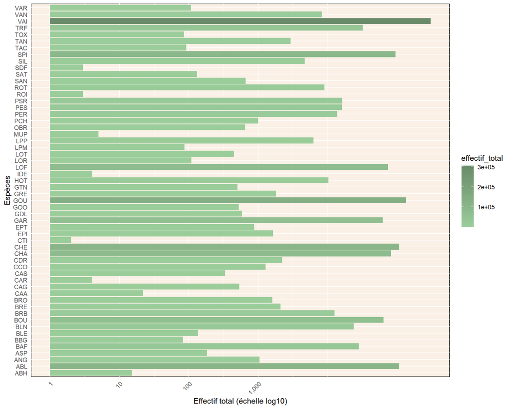

```r
ggplot(esp_effectif,
       aes(x = esp_code_alternatif, y = effectif_total, fill = effectif_total)) +
  geom_col() +
  scale_fill_gradient(low = "darkseagreen3", high = "darkseagreen4") +
  scale_y_log10(
    name = "Effectif total (échelle log10)",
    breaks = c(1, 10, 100, 1000),
    labels = comma
  ) +
  coord_flip() +
  theme_minimal() +
  labs(x = "Espèces", y = "Effectif total") +
  theme(
    axis.text.x = element_text(angle = 45, hjust = 1),
    panel.grid.major = element_line(color = "#ffffff"),
    panel.grid.minor = element_line(color = "#ffffff"),
    panel.background = element_rect(fill = "#faf0e6")
  )
```

## 5.3 Construction du jeu de donnée finale **esp_ope_selection**

Pour construire le df **esp_ope_selection**, pusieurs jeu de donnée vont être fusionné :

1. **tax_ref_uicn** possède les nom commun et nom complet scientique des espèces de poissons.
2. **tax_ref_aspe** possède les codes espèces de la base aspe permettant des jointures entre tables.
3. **liste_esp_bfc** possède les codes espèces, une liste des espèces de 2016 sur la région avec les statuts d’autochtonies.
4. **base_liste_complete_bfc_aspe** correspond au df de la période complète régionale de la base aspe toute stations confondues, export présent directement dans *processed_data*.
5. **liste_correc_autochtonie** correspond à une liste provisoire issus des fusions des df précédent. Il est présent en export dans *processed_data*
6. **liste_bfc_sp_cor** correspond à un df de toutes les espèces présentes en BFC avec les noms taxref, les codes aspe, les statut d’autochtonie par bassins- versants et quelques corrections. Il est présent en export dans *processed_data*. Il a été construit à partir de la fusion des jeux de données précédents ainsi qu’un ajout de correction manuellement sur de nouvelles colonnes, sur Excel. Il est une correction directe du df précédent **liste_correc_autochtonie**.
7. **esp_ope_selection** correspond au df de la période *2007-2025* avec les stations sélectionnées pour l’analyse des données.

### 5.3.1 Ajout des noms espèces - taxref v18 au dataframe **esp_ope_selection**

On cherche à intégrer les libelle de nom d’espèces taxref à notre dataframe **esp_ope_selection** in fine, pour cela :

- On joint le df avec les noms taxref au df avec les codes espèces Aspe
- On joindra ce nouveau df **tax_ref_ape** au df **esp_ope_selection**

```r
# Jointure taxref avec ref taxe aspe
tax_ref_aspe <- tax_ref_aspe %>%
  left_join(tax_ref_uicn, by = "code_taxref") %>%
  select(esp_code_alternatif, ordre, nom_vernaculaire, nom_latin, nom_valide, nom_commun, nom_scientifique, code_taxref)
```

### 5.3.2 Liste d’espèces complète 2016 BFC à partir de la base ASPE (période 2007-2025)

```r
esp_list <- liste_esp_bfc %>%
  full_join(tax_ref_aspe, by = "esp_code_alternatif")
```

```r
esp_full_list <- esp_list %>%
  full_join(esp_effectif, by = "esp_code_alternatif") %>% # jointure effectif à la liste bfc
  filter(!(is.na(Introduction) & is.na(effectif_total))) %>%
  select(ordre, nom_vernaculaire,nom_latin, nom_commun, nom_scientifique, nom_valide,esp_code_alternatif, Introduction, effectif_total)
```

### 5.3.3 Liste d’espèces période complete de BFC sélectionnées à partir de la base ASPE

```r
# base_liste_complete_bfc_aspe <- readr::read_delim('../processed_data/liste_complete_aspe_bfc.csv') %>%
#   select(
#     ordre,
#     nom_vernaculaire,
#     nom_latin,
#     nom_commun,
#     nom_scientifique,
#     nom_valide,
#     Introduction,
#     esp_code_alternatif
#   )
```

```r
# esp_full_list_eff <- esp_full_list %>%
#   select(effectif_total, esp_code_alternatif)
#
# liste_complete_bfc_lrr <- base_liste_complete_bfc_aspe %>%
#   left_join(esp_full_list_eff, by = "esp_code_alternatif")
```

```r
# liste_correc_autochtonie <-  liste_bio_autochtonie %>%
#   select(esp_code_alternatif,
#          statut_autochtonie,
#          categorie_lr_france_2019)
#
# liste_complete_bfc_lrr <- liste_complete_bfc_lrr %>%
#   left_join(liste_correc_autochtonie, by = "esp_code_alternatif") %>%
#   select(
#     ordre,
#     nom_commun,
#     nom_valide,
#     esp_code_alternatif,
#     statut_autochtonie ,
#     effectif_total,
#     categorie_lr_france_2019
#   ) %>%
#   rename(nom_vernaculaire_v18 = nom_commun,
#          nom_scientifique_v18 = nom_valide)
```

```r
#write_excel_csv(liste_complete_bfc_lrr, "../processed_data/liste_esp_lrr_bfc.csv")
```

### 5.3.4 Après expertise de Gael Denys, voici une liste corrigée d’espèces.

```r
liste_bfc_sp_cor <- readxl::read_xlsx("../processed_data/liste_esp_lrr_bfc_GD.xlsx") %>%
  clean_names() %>%
  select(esp_code_alternatif, statut_autochtonie, effectif_total, categorie_lr_france_2019, statut_rhin, statut_seine, statut_loire, statut_rhone)
```

```r
liste_bfc_sp_cor <- liste_bfc_sp_cor %>%
  left_join(tax_ref_aspe, by = "esp_code_alternatif") %>%
  select(
    ordre,
    nom_valide,
    nom_vernaculaire,
    esp_code_alternatif,
    statut_autochtonie,
    effectif_total,
    categorie_lr_france_2019,
    statut_rhin,
    statut_seine,
    statut_loire,
    statut_rhone,
    nom_commun
  )
```

```r
liste_bfc_sp_cor <- liste_bfc_sp_cor %>%
  filter(!esp_code_alternatif == "TRL") %>% # On ne ^prend pas en compte les ecotypes de truite dans la liste rouge
  mutate(statut_loire = fct_recode(statut_loire, "endémique" = "endémqiue"))
```

```r
liste_bfc_sp_cor <- liste_bfc_sp_cor %>%

  mutate(autochtonie_new = if_else(if_any(
    c(statut_rhone, statut_seine, statut_loire),
    ~ . %in% c(
      "a priori introduit avant 1500",
      "endémique",
      "introduit avant 1500",
      "natif",
      "natif*",
      "éteint"
    )
  ), "autochtone", "allochtone"))
```

```r
liste_bfc_sp_cor <- liste_bfc_sp_cor %>%
  # filter(autochtonie_new == "autochtone") %>%
  select(
    ordre,
    nom_valide,
    nom_commun,
    esp_code_alternatif,
    autochtonie_new,
    #effectif_total,
    #statut_rhin,
    # statut_seine,
    # statut_loire,
    #  statut_rhone,
    categorie_lr_france_2019
  )
```

```r
# liste_bfc_sp_cor <- liste_bfc_sp_cor %>%
#     mutate(effectif_total = na_if(effectif_total, "NA"))
```

```r
table_liste_bfc_sp_cor_exp <- liste_bfc_sp_cor %>%
  rename(
    "Nom scientifique" = nom_valide,
    "Code espèce" = esp_code_alternatif,
    "Statut" = autochtonie_new,
    "LRR France 2019" = categorie_lr_france_2019,
    "Nom vernaculaire" = nom_commun,
    "Ordre" = ordre
  ) %>%
  arrange(desc(Statut))

# write_excel_csv(table_liste_bfc_sp_cor_exp,
#                 "../processed_data/liste_bfc_sp_cor_exp.csv")
```

```r
table_liste_bfc_sp_cor <- liste_bfc_sp_cor %>%
  rename(
    "Nom scientifique" = nom_valide,
    "Code espèce" = esp_code_alternatif,
    "Statut" = autochtonie_new,
    "LRR France 2019" = categorie_lr_france_2019
  ) %>%
  arrange(desc(Statut)) %>%
  flextable::flextable() %>%
  flextable::autofit() %>%
  flextable::colformat_int(j = c(1, 3), big.mark = " ") %>%
  flextable::style()
table_liste_bfc_sp_cor
```

| ordre | Nom scientifique | nom_commun | Code espèce | Statut | LRR France 2019 |
| --- | --- | --- | --- | --- | --- |
| Acipenseriformes | Acipenser sturio Linnaeus, 1758 | Esturgeon, Esturgeon européen, Esturgeon de l'Europe Occidentale | EST | autochtone | CR |
| Anguilliformes | Anguilla anguilla (Linnaeus, 1758) | Anguille d’Europe, Anguille européenne | ANG | autochtone | CR |
| Clupeiformes | Alosa alosa (Linnaeus, 1758) | Grande alose, Alose vraie | ALA | autochtone | CR |
| Clupeiformes | Alosa fallax (Lacepède, 1803) | Alose feinte atlantique | ALF | autochtone |  |
| Cypriniformes | Abramis brama (Linnaeus, 1758) | Brème commune | BRE | autochtone | LC |
| Cypriniformes | Alburnoides bipunctatus (Bloch, 1782) | Spirlin | SPI | autochtone | LC |
| Cypriniformes | Alburnus alburnus (Linnaeus, 1758) | Ablette | ABL | autochtone | LC |
| Cypriniformes | Barbatula barbatula (Linnaeus, 1758) | Loche franche | LOF | autochtone | LC |
| Cypriniformes | Barbus barbus (Linnaeus, 1758) | Barbeau fluviatile | BAF | autochtone | LC |
| Cypriniformes | Blicca bjoerkna (Linnaeus, 1758) | Brème bordelière | BRB | autochtone | LC |
| Cypriniformes | Chondrostoma nasus (Linnaeus, 1758) | Nase commun, Hotu, Alonge, Aucon, Chiffe, Fera, Muge, Mulet, Nase, Nez, Seuffre, Tunar, Âme noire, Écrivain | HOT | autochtone | LC |
| Cypriniformes | Cobitis taenia Linnaeus, 1758 | Loche de rivière, Loche épineuse | LOR | autochtone | NT |
| Cypriniformes | Cyprinus carpio Linnaeus, 1758 | Carpe commune, Carpat, Carpeau, Escarpo, Kerpaille | CCO | autochtone | NA |
| Cypriniformes | Gobio gobio (Linnaeus, 1758) | Goujon | GOU | autochtone | LC |
| Cypriniformes | Leuciscus burdigalensis Valenciennes in Cuvier & Valenciennes, 1844 | Vandoise rostrée | VAR | autochtone | NT |
| Cypriniformes | Leuciscus leuciscus (Linnaeus, 1758) | Vandoise | VAN | autochtone | LC |
| Cypriniformes | Misgurnus fossilis (Linnaeus, 1758) | Loche d'étang | LOE | autochtone | EN |
| Cypriniformes | Parachondrostoma toxostoma (Vallot, 1837) | Toxostome, Sofie, Soiffe | TOX | autochtone | NT |
| Cypriniformes | Phoxinus phoxinus (Linnaeus, 1758) | Vairon | VAI | autochtone | LC |
| Cypriniformes | Phoxinus fayollarum Denys, Dettai, Persat, Daszkiewicz, Hautecoeur & Keith, 2020 |  | VAF | autochtone |  |
| Cypriniformes | Phoxinus septimaniae Kottelat, 2007 | Vairon du Languedoc | VAC | autochtone |  |
| Cypriniformes | Rutilus rutilus (Linnaeus, 1758) | Gardon | GAR | autochtone | LC |
| Cypriniformes | Scardinius erythrophthalmus (Linnaeus, 1758) | Rotengle | ROT | autochtone | LC |
| Cypriniformes | Squalius cephalus (Linnaeus, 1758) | Chevesne commun, Chevaine commun | CHE | autochtone | LC |
| Cypriniformes | Telestes souffia (Risso, 1827) | Blageon | BLN | autochtone | LC |
| Cypriniformes | Tinca tinca (Linnaeus, 1758) | Tanche | TAN | autochtone | LC |
| Esociformes | Esox lucius Linnaeus, 1758 | Brochet | BRO | autochtone | VU |
| Gadiformes | Lota lota (Linnaeus, 1758) | Lote | LOT | autochtone | VU |
| Gasterosteiformes | Gasterosteus aculeatus Linnaeus, 1758 | Épinoche à trois épines, Arselet, Cordonnier, Crève-valet, Épinart, Épinglet, Estancelin, Étrangle-chat, Écharde, Quatre-épées | EPI | autochtone | LC |
| Gasterosteiformes | Pungitius pungitius (Linnaeus, 1758) | Épinochette | EPT | autochtone | DD |
| Gasterosteiformes | Pungitius laevis (Cuvier, 1829) | Épinochette | EPL | autochtone |  |
| Mugiliformes | Chelon ramada (Risso, 1827) | Mulet porc | MUP | autochtone | LC |
| Perciformes | Perca fluviatilis Linnaeus, 1758 | Perche | PER | autochtone | LC |
| Perciformes | Zingel asper (Linnaeus, 1758) | Apron du Rhône | APR | autochtone | EN |
| Petromyzontiformes | Lampetra fluviatilis (Linnaeus, 1758) | Lamproie de rivière, Lamproie fluviatile | LPR | autochtone | VU |
| Petromyzontiformes | Lampetra planeri (Bloch, 1784) | Lamproie de Planer, Petite lamproie, Lamproie de ruisseau européenne | LPP | autochtone | LC |
| Petromyzontiformes | Petromyzon marinus Linnaeus, 1758 | Lamproie marine | LPM | autochtone | EN |
| Salmoniformes | Salmo salar Linnaeus, 1758 | Saumon de l'Atlantique, Saumon atlantique | SAT | autochtone | NT |
| Salmoniformes | Salmo trutta Linnaeus, 1758 | Truite de mer, Truite commune, Truite d'Europe | TRF | autochtone | LC |
| Salmoniformes | Thymallus thymallus (Linnaeus, 1758) | Ombre commun | OBR | autochtone | VU |
| Salmoniformes | Thymallus ligericus Persat, Weiss, Froufe, Secci-Petretto & Denys, 2019 | Ombre d'Auvergne | OBA | autochtone |  |
| Scorpaeniformes | Cottus gobio Linnaeus, 1758 | Chabot, Chabot commun | CHA | autochtone | LC |
| Scorpaeniformes | Cottus perifretum Freyhof, Kottelat & Nolte, 2005 | Bavard, Chabot, Chabot celtique, Chabot fluviatile, Têtard | CHF | autochtone |  |
| Cypriniformes | Carassius auratus (Linnaeus, 1758) | Carassin doré, Poisson rouge | CAA | allochtone | NA |
| Cypriniformes | Carassius carassius (Linnaeus, 1758) | Carassin commun | CAS | allochtone | LC |
| Cypriniformes | Carassius gibelio (Bloch, 1782) | Carassin argenté | CAG | allochtone | NA |
| Cypriniformes | Ctenopharyngodon idella (Valenciennes, 1844) | Amour blanc (L'), Carpe amour, Carpe herbivore, Chinoise | CTI | allochtone | NA |
| Cypriniformes | Gobio occitaniae Kottelat & Persat, 2005 | goujon occitan, Goujon du Languedoc | GOO | allochtone | LC |
| Cypriniformes | Hypophthalmichthys molitrix (Valenciennes, 1844) | Carpe argentée | CAR | allochtone | NA |
| Cypriniformes | Leucaspius delineatus (Heckel, 1843) | L'Able de Heckel | ABH | allochtone | DD |
| Cypriniformes | Leuciscus aspius (Linnaeus, 1758) | Aspe | ASP | allochtone | NA |
| Cypriniformes | Leuciscus idus (Linnaeus, 1758) | Gardon rouge, Ide mélanote | IDE | allochtone | DD |
| Cypriniformes | Phoxinus csikii Hankó, 1922 | Vairon du Danube | VAD | allochtone |  |
| Cypriniformes | Pseudorasbora parva (Temminck & Schlegel, 1846) | Pseudorasbora, Goujon asiatique | PSR | allochtone | NA |
| Cypriniformes | Rhodeus amarus (Bloch, 1782) | Bouvière | BOU | allochtone | LC |
| Cypriniformes | Scardinius hesperidicus Bonaparte, 1845 |  | ROI | allochtone | NA |
| Gobiiformes | Neogobius melanostomus (Pallas, 1814) | Gobie à tache noire | GTN | allochtone | NA |
| Gobiiformes | Proterorhinus semilunaris (Heckel, 1837) | Gobie demi-lune, Gobie à nez tubulaire | GDL | allochtone | NA |
| Perciformes | Ambloplites rupestris (Rafinesque, 1817) | Crapet de roche | CDR | allochtone | NA |
| Perciformes | Gymnocephalus cernua (Linnaeus, 1758) | Grémille | GRE | allochtone | LC |
| Perciformes | Lepomis gibbosus (Linnaeus, 1758) | Perche-soleil, Boer, Calicoba, Perche arc-en-ciel, Perche argentée, Perche dorée, Poisson tricolore, Poisson-soleil, Crapet-soleil | PES | allochtone | NA |
| Perciformes | Micropterus salmoides (Lacepède, 1802) | Achigan à grande bouche, Black-bass à grande bouche, Perche d'Amérique, Perche noire, Perche truite, Perche truitée | BBG | allochtone | NA |
| Perciformes | Salariopsis fluviatilis (Asso, 1801) | Blennie fluviatile | BLE | allochtone | LC |
| Perciformes | Sander lucioperca (Linnaeus, 1758) | Sandre, Perche-brochet | SAN | allochtone | NA |
| Salmoniformes | Coregonus Linnaeus, 1758 | Corégones | COR | allochtone | NA |
| Salmoniformes | Oncorhynchus mykiss (Walbaum, 1792) | Truite arc-en-ciel | TAC | allochtone | NA |
| Salmoniformes | Salvelinus fontinalis (Mitchill, 1814) | Omble de fontaine, Saumon de fontaine, Truite mouchetée | SDF | allochtone | NA |
| Siluriformes | Ameiurus melas (Rafinesque, 1820) | Poisson-chat | PCH | allochtone | NA |
| Siluriformes | Silurus glanis Linnaeus, 1758 | Silure glane | SIL | allochtone | NA |

Après avoir construit la liste d’espèces avec les noms d’espèces complets taxrefv18, on peut ajouter notre sélection dans notre jeu de données initiale **esp_ope_selection**.

```r
liste_bfc_sp_cor_join <- liste_bfc_sp_cor %>%
  select(esp_code_alternatif, autochtonie_new)

esp_ope_selection <- esp_ope_selection %>%
  left_join(liste_bfc_sp_cor_join, by = "esp_code_alternatif")
```

## 5.4 Vérification identification GOU / GOO :

Dans les stations du **“Ternin à Chissey-En-Morvan”** : 8837 et du **“Mechet à Saint-Prix”** 8842 : le GOU à été changé vers 2018 en GOO. Avant cette date, les goujons occitan étaient identifiée comme GOU.

```r
#write_excel_csv(liste_bfc_sp_cor, "../processed_data/liste_bfc_sp_cor.csv")
```

## 5.5 Pourcentage d’occurrence

Le tableau *tab_occurrence* regroupant toutes les combinaisons d’opérations et d’espèces possible est réalisé. Il sera ensuite utilisé pour calculer les pourcentages d’occurrence des espèces présentes dans le jeu de données initiale *esp_ope_selection*.

```r
ope_id <- unique(esp_ope_selection$ope_id)
esp_code_alternatif <- unique(esp_ope_selection$esp_code_alternatif)

ope_annees <- esp_ope_selection %>% # Création d'un df contenant toutes les opérations et années associées
  ungroup() %>%
  select(ope_id,
         annee) %>%
  distinct()

tab_occurrence <- crossing(ope_id, esp_code_alternatif)
```

À partir de *tab_occurrence*, le calcul du pourcentage d’occurrence peut être réalisé. Il s’agit du nombre de pêches avec une présence de l’espèce divisé par le nombre total de pêches. Les calculs des pourcentages d’occurrence sont stockés dans le jeu de données *tab_taux_occurrence* regroupant les densités surfaciques moyennes par espèce ainsi que les taux d’occurrence.

```r
tab_taux_occurrence <- tab_occurrence %>%
  left_join(ope_esp_densite_cal) %>%
  mutate(valeur_oc = ifelse(is.na(valeur), 0, valeur)) %>%
  left_join(ope_annees) %>%
  group_by(esp_code_alternatif,
           annee) %>%
  mutate(n_ope = n_distinct(ope_id),
            n_oc = n_distinct(ope_id[valeur_oc > 0]),
            taux_occurrence = (n_oc / n_ope)*100) %>%
  group_by(esp_code_alternatif) %>%
  mutate(taux_occurrence_moy = mean(taux_occurrence)) %>%
  select(esp_code_alternatif,
         taux_occurrence_moy) %>%
  distinct()
```

## 5.6 Tableau final des densités surfaciques et des occurrences

Un tableau final regroupant les densités surfaciques moyennes et les occurrences moyennes des espèces est réalisé (relatifs à la sélection des stations et opérations réalisée dans le script 01_preatreatment_ope).

```r
tab_densite_occurrence <- left_join(esp_densite_moyenne, tab_taux_occurrence, by = "esp_code_alternatif")
```

# 6 Représentation graphique

En amont de la réalisation d’une représentation graphique, les statuts de présence des espèces dans la précédente liste rouge régionale est renseigné dans une nouvelle colonne *statut_lrr* du dataframe *tab_densite_occurrence*. Cela permettra d’observer où se situent chaque espèce dans la relation pourcentage occurrence moyenne / densité surfacique moyenne, ainsi que leur présence / absence dans la précédente liste rouge régionale.

```r
tab_densite_occurrence <- tab_densite_occurrence %>%
  mutate(statut_lrr = ifelse (esp_code_alternatif %in% params$especes_lrr_FC,
                           "Liste Rouge Régionale FC 2014",
                           "Présente en Bourgogne-Franche-Comté"))
```

La représentation graphique est effectuée : par soucis de représentation, les axes sont mis en échelles logarithmiques.

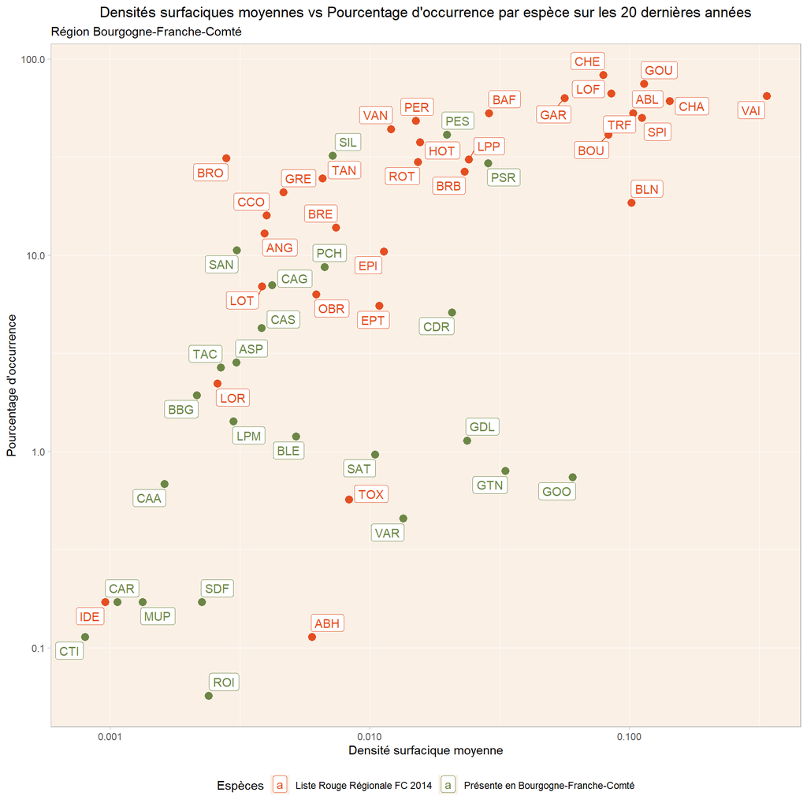

```r
gg_base <- ggplot(tab_densite_occurrence,
       aes(x = densite_moy,
           y = taux_occurrence_moy,
           label = esp_code_alternatif,
           color = statut_lrr)) +
  geom_point(size = 3,
             shape = 16) +
  labs(title = "Densités surfaciques moyennes vs Pourcentage d'occurrence par espèce sur les 20 dernières années",
       subtitle = "Région Bourgogne-Franche-Comté",
       x = "Densité surfacique moyenne",
       y = "Pourcentage d'occurrence") +
  scale_color_manual(values = wesanderson::wes_palette("AsteroidCity1")[3:5],
                     name = "Espèces") +
  scale_x_log10() +  # axe des x en échelle logarithmique
  scale_y_log10() +  # axe des y en échelle logarithmique
  theme_light(base_size = 11) +
  theme(plot.title = element_text(hjust = 0.5),
        panel.grid.major = element_line(color = "#ffffff", size = 0.1),
        panel.grid.minor = element_line(color = "#ffffff"),
        panel.background = element_rect(fill = "#faf0e6"),
        legend.position = "bottom")

gg_texte_usuel <- gg_base + geom_label_repel() # afin d'éviter les chevauchements entre les différentes étiquettes
gg_texte_usuel
```

```r
tab_densite_occurrence$esp_code_alternatif
```

```
##  [1] "ABH" "ABL" "ANG" "ASP" "BAF" "BBG" "BLE" "BLN" "BOU" "BRB" "BRE" "BRO"
## [13] "CAA" "CAG" "CAR" "CAS" "CCO" "CDR" "CHA" "CHE" "CTI" "EPI" "EPT" "GAR"
## [25] "GDL" "GOO" "GOU" "GRE" "GTN" "HOT" "IDE" "LOF" "LOR" "LOT" "LPM" "LPP"
## [37] "MUP" "OBR" "PCH" "PER" "PES" "PSR" "ROI" "ROT" "SAN" "SAT" "SDF" "SIL"
## [49] "SPI" "TAC" "TAN" "TOX" "TRF" "VAI" "VAN" "VAR"
```

À partir de ce graphique, nous pouvons éliminer les espèces qui sont trop rares, c’est-à-dire ayant une densité surfacique moyenne et un taux d’occurrence très faibles (pour lesquelles nous n’avons pas assez de données - cela correspond aux espèces situées en bas à gauche du graphique). Les espèces ayant le plus de données sur lesquelles s’appuyer apparaissent en haut à droite du graphique : ce sont les espèces qui ont une forte occurrence ainsi qu’une forte densité surfacique moyenne.

# 7 Liste finale d’espèces à evaluer - Autochtonie

```r
especes_lrr_2014 <- c("LOT","LOE","CHE","BRO","BOU","ANG","PER","BAF","EPT","ABH","BRE","EPI","CCO","CHA","HOT","VAI","TAN","BLN","VAN","TRF","LPP","OBR","ROT","ABL","GAR","IDE","LOF","TOX","GRE","BRB","SPI","GOU","LPM","LOR","LPP")

mes_especes <- c("ABL","ANG","BAF","BLN","BRB", "BRE","BRO","CCO","CHA","CHE", "EPI", "EPT", "GAR", "GOU","HOT","LOF","LOR", "LOT","LPM" ,"LPP", "OBR", "PER", "ROT", "SAT", "SPI", "TAN", "TOX", "TRF","VAI","VAN","VAR")
```

```r
esp_ope_selection <- esp_ope_selection %>%
  filter(autochtonie_new == "autochtone") %>%
  filter(esp_code_alternatif %in% mes_especes)
```

```r
table(esp_ope_selection$esp_code_alternatif)
```

```
##
##   ABL   ANG   BAF   BLN   BRB   BRE   BRO   CCO   CHA   CHE   EPI   EPT   GAR
##  5471  1041  8382  3135  2985   864  1535   932  7734 32210   346   203 14729
##   GOU   HOT   LOF   LOR   LOT   LPM   LPP   OBR   PER   ROT   SAT   SPI   TAN
##  9549  4996  4755    63   422    69  1694   510  6583  2526    84  5400  1434
##   TOX   TRF   VAI   VAN   VAR
##    26 16128  4210  4347   107
```

“ABL” “ANG” “BAF” “BLN” “BRB” “BRE” “BRO” “CCO” “CHA” “CHE” “EPI” “EPT” “GAR” “GOU” “HOT” “LOF” “LOR” “LOT” “LPM” “LPP” “OBR” “PER” “ROT” “SAT” “SPI” “TAN” “TOX” “TRF” “VAI” “VAN” “VAR”

```r
tab_occurrence_esp <- tab_occurrence %>%
  filter(esp_code_alternatif%in% mes_especes)
```

```r
ope_esp_densite_cal <- ope_esp_densite_cal %>%
  filter(esp_code_alternatif%in% mes_especes)
```

### 7.0.1 Definition / Verification de l’Autochtonie des espèces / Temps de génération des espèces

```r
liste_bio <- readxl::read_xlsx("../processed_data/liste_complete_lrr_correction.xlsx") %>%
  clean_names() %>%
  select(
    esp_code_alternatif,
    maturite_m,
    maturite_f,
    maturite_an,
    maturite_bq,
    longevite_bq,
    longevite_an
  ) %>%
  filter(esp_code_alternatif%in% mes_especes)
```

```r
# liste_bio_join <- liste_bio %>%
#   left_join(liste_bfc_sp_cor, by = "esp_code_alternatif") %>%
#   select(
#     # ordre,
#     nom_valide,
#     esp_code_alternatif,
#     autochtonie_new,
#     maturite_m,
#     maturite_f,
#     maturite_an,
#     maturite_bq,
#     longevite_bq,
#     longevite_an,
#     # effectif_total,
#     categorie_lr_france_2019
#   )
#
# liste_bio <- liste_bio_join %>%
#   filter(
#     autochtonie_new == "autochtone"#,
#     #!is.na(effectif_total)
#   )
```

```r
traits_biologiques <- readxl::read_xlsx("../raw_data/traits_biologiques.xlsx")

traits_biologiques <- traits_biologiques %>%
  select(esp_code_alternatif, temps_generation, age_maturite)
```

```r
liste_bio_join <- liste_bio %>%
  left_join(traits_biologiques)
```

```r
# write_excel_csv(liste_bio_join, "../processed_data/temps_de_generation_pro.csv")
```

# 8 Sauvegarde

Sauvegarde pour le script suivant : script 20_pre_traitements_donnees_ope_especes.

```r
save(
  especes_lrr_2014,
  mes_especes,
  esp_ope_selection,
  ope_esp_densite_cal,
  tab_occurrence_esp,
  liste_bfc_sp_cor,
  file = "../processed_data/selection_especes.rda"
)
```

# 9 Références bibliographiques

Irz, P., Mondy, C., Richard, B. Bonnafoux, L. (2024). aspe: An R package to analyse and visualise river fish data in France. R package version 0.4.1, https://github.com/PascalIrz/aspe/